# Modul 3: Analisis Statistik Inferensial (Parametrik)

Azwan Nazamuddin

2024-10-19

# Modul 3: Analisis Statistik Inferensial (Parametrik)

### Objectives Praktikum

1. Praktikan mampu memahami prinsip-prinsip dasar analisis statistik inferensial parametrik dengan metode estimasi parameter dan pengujian hipotesa
2. Praktikan mampu melakukan analisis inferensial parametrik dengan metode estimasi parameter dan pengujian hipotesa dengan pemrograman R pada RStudio

## Review Teori

Analisis statistik inferensial adalah metode analisis yang membantu dalam membuat kesimpulan umum tentang karakteristik populasi berdasarkan apa yang di analisis dari data sampel yang diperoleh dari populasi tersebut. Penerapan analisis statistik inferensial dapat dilakukan dalam dua bentuk yaitu estimasi parameter dan pengujian hipotesis. Pada praktikum ini, yang akan dibahas adalah estimasi parameter dan pengujian hipotesis. Selain itu, fokus pendekatan statistik pada praktikum ini adalah statistik klasik (*Frequentist*)*. [**Cari tahu lebih lanjut apa itu frequentist (dan juga bayesian)**](https://amplitude.com/blog/frequentist-vs-bayesian-statistics-methods)*[**.**](https://amplitude.com/blog/frequentist-vs-bayesian-statistics-methods)

### Estimasi Parameter

Estimasi parameter adalah suatu perkiraan parameter populasi yang dibuat pada apa yang diketahui tentang sampel. Estimasi digolongkan menjadi dua yaitu estimasi titik (*point estimation*) dan estimasiinterval.

1. **Estimasi Titik (*Point Estimation*)**

   Sebuah nilai tunggal yang digunakan untuk mengestimasi sebuah parameter disebut titik estimator, sedangkan proses untuk mengestimasi titik tersebut disebut estimasi titik (Harinaldi, 2005). Pada estimasi titik, nilainya hanya ada satu dan sangat mengandalkan asumsi parameter. Estimasi titik lebih mudah dalam hal penghitungan, tetapi penaksirannya sangat diragukan karena sangat jarang nilai karakteristik populasi sama persis dengan nilai karakteristik sampel. Hasil estimasi titik juga tidak memberikan tingkat kepercayaan tertentu.
2. **Estimasi Interval**

   Estimasi interval adalah penaksiran populasi dengan nilai-nilai dalam suatu interval tertentu. Dasar adanya estimasi interval adalah karena pada setiap penaksiran pasti mengandung peluang kesalahan. Estimasi interval pada statistik inferensial klasik (*Confidence Interval*).
   - Estimasi Interval Rata-rata Populasi Satu Sampel

     ```
       a. Sampel Besar

       $CI =  \bar{X} \pm Z\frac{S_{x}}{\sqrt{n-1}}$

       b. Sampel Kecil

       $CI =  \bar{X} \pm t\frac{S_{x}}{\sqrt{n-1}}$
     ```

     - Estimasi Interval Perbedaan Rata-Rata Berpasangan
       1. Sampel Besar

       $CI = \bar{D} \pm Z\frac{S_{D}}{\sqrt{n-1}}$
       2. Sampel Kecil

       $CI = \bar{D} \pm t\frac{S_{D}}{\sqrt{n-1}}$
     - Estimasi Interval Perbedaan Rata-Rata Independen
       1. Sampel Besar

       $CI = (\bar{X_{1}} - \bar{X_{2}}) \pm t \sqrt{\frac{S_{1}^{2}}{n_{1}} + \frac{S_{2}^{2}}{n_{2}}}$
       2. Sampel Kecil

       $CI = (\bar{X_{1}} - \bar{X_{2}}) \pm t \sqrt{\frac{S_{1}^{2}}{n_{1} - 1} + \frac{S_{2}^{2}}{n_{2} - 1}}$
     - Estimari Interval Proporsi

       $CI = P_{S} \pm \sqrt{\frac{P_{\mu}(1-P_{\mu})}{n}}$

       $CI = {(P}_{S1} + P_{S2}) \pm Z\sigma_{P - P}$

### Pengujian Hipotesis

Pengujian hipotesis juga terbagi dua, yaitu pengujian hipotesis parametrik untuk data yang memiliki distribusi normal dan pengujian hipotesis non parametrik untuk data yang tidak memerlukan distribusi normal. Pengujian hipotesis parametrik sendiri terdiri dari uji satu sampel (uji proporsi dan uji rata-rata) dan uji dua sampel, yang meliputi dua sampel non independen (uji uji perbedaan rata-rata berpasangan), dan dua sampel independen (uji perbedaan rata-rata independen, dan uji perbedaan dua proporsi).

Prosedur pengujian hipotesa terdiri dari:

1. Penentuan asumsi yang terdiri dari asumsi mengenai proses pengambilan sampel, tipe skala pengukuran, dan bentuk distribusi sampling.
2. Pernyataan hipotesa awal, dengan $o$ merupakan suatu pernyataan tidak ada perbedaan, dan $i$ : suatu pernyataan yang secara langsung bertentangan dengan $o$
3. Pemilihan distribusi sampling dan penentuan wilayah kritis, dengan mengukur wilayah di bawah distribusi dengan menggunakan distribusi yang sesuai. Wilayah kritis terdiri dari wilayah di bawah distribusi sampling yang mencakup semua hasil sampel yang tidak mungkin dan disebut daerah penolakan $o$. Ukuran wilayah kritis diungkapkan dalam $α$ (proporsi dari seluruh wilayah yang tercakup dalam wilayah kritis).
4. Penghitungan statistik uji untuk mengevaluasi probabilitas beberapa hasil sampel tertentu, nilai sampel harus diubah ke dalam nilai standar, sesuai dengan distribusi yang digunakan. Apabila menggunakan ditribusi $z$ maka nilai sampel diubah dalan skor $z$, dan apabila menggunakan distribusi $t$ maka nilai sampel diubah dalam skor $t$.

$Z_{hitung} =\frac{Statistik Parameter}{Standard Error}$

*Nilai Z biasanya cocok untuk sampel besar, sedangkan nilai t dapat digunakan untuk baik sampel besar maupun kecil, sehingga pada software statistik seperti Stata, lebih sering digunakan nilai t saja.*

5. Membuat keputusan, keputusan dibuat dengan membandingkan statistik uji ($z$ hitung) dengan wilayah kritis ($z$ tabel). $o$ ditolak bila statistik uji di wilayah kritis dan $o$ diterima bila statistik uji berada di wilayah tidak kritis.

## Hands-on Praktikum

Dalam praktikum ini akan dilakukan analisis inferensial berupa estimasi rata-rata satu sampel, estimasi rata-rata dua sampel, estimasi proporsi satu sampel, uji rata-rata satu sampel kecil, uji perbedaan rata-rata independen 2 sampel kecil, uji perbedaan rata-rata berpasangan 2 sampel kecil, uji proporsi satu sampel, serta uji proporsi dua sampel independen.

Dataset yang digunakan untuk praktikum ini adalah dataset `Airbnb Prices in European Cities` yang diambil dari portal `Kaggle`. Berikut adalah penjelasan lebih lanjut terkait dataset yang tersedia pada portal `Kaggle`.

*This dataset provides a comprehensive look at Airbnb prices in some of the most popular European cities. Each listing is evaluated for various attributes such as room types, cleanliness and satisfaction ratings, bedrooms, distance from the city centre, and more to capture an in-depth understanding of Airbnb prices on both weekdays and weekends. Using spatial econometric methods, we analyse and identify the determinants of Airbnb prices across these cities. Our dataset includes information such as realSum (the total price of the listing), room_type (private/shared/entire home/apt), host_is_superhost (boolean value indicating if host is a superhost or not), multi (indicator whether listing is for multiple rooms or not), biz (business indicator) , guest_satisfaction_overall (overall rating from guests camparing all listings offered by host ), bedrooms, dist (distance from city center) , lng & lat coordinates for location identification etc. We hope that this data set offers insight into how global markets are affected by social dynamics and geographical factors which in turn determine pricing strategies for optimal profitability!*

Dalam kasus praktikum ini, dataset yang digunakan berfokus pada data harga Airbnb di London, UK pada saat weekend.

```r
data <- read.csv("data/london_weekends.csv")
head(data)
```

```
##    realSum       room_type room_shared room_private person_capacity
## 1 121.1223    Private room       FALSE         TRUE               2
## 2 195.9124    Private room       FALSE         TRUE               2
## 3 193.3253    Private room       FALSE         TRUE               3
## 4 180.3899    Private room       FALSE         TRUE               2
## 5 405.7010 Entire home/apt       FALSE        FALSE               3
## 6 354.1946 Entire home/apt       FALSE        FALSE               2
##   host_is_superhost multi biz cleanliness_rating guest_satisfaction_overall
## 1             FALSE     0   0                  6                         69
## 2             FALSE     1   0                 10                         96
## 3             FALSE     1   0                 10                         95
## 4             FALSE     1   0                  9                         87
## 5             FALSE     0   1                  7                         65
## 6             FALSE     0   1                  9                         93
##   bedrooms     dist metro_dist attr_index attr_index_norm rest_index
## 1        1 5.734117  0.4370940   222.8822        15.49341   470.0885
## 2        1 4.788905  1.4640505   235.3858        16.36259   530.1335
## 3        1 4.596677  0.4503062   268.9138        18.69325   548.9876
## 4        1 2.054769  0.1326705   472.3813        32.83707  1021.2711
## 5        0 4.491277  0.3541075   318.4915        22.13958   692.7754
## 6        0 4.467894  0.3507494   321.8646        22.37406   703.0686
##   rest_index_norm      lng      lat
## 1        8.413765 -0.04975 51.52570
## 2        9.488466 -0.08475 51.54210
## 3        9.825922 -0.14585 51.54802
## 4       18.278973 -0.10611 51.52108
## 5       12.399473 -0.18797 51.49399
## 6       12.583702 -0.18805 51.49473
```

| Column Name | Description | Data Type |
| --- | --- | --- |
| realSum | The total price of the Airbnb listing. | Numeric |
| room_type | The type of room being offered (e.g. private, shared, etc.) | Categorical |
| room_shared | Whether the room is shared or not. | Boolean |
| room_private | Whether the room is private or not. | Boolean |
| person_capacity | The maximum number of people that can stay in the room. | Numeric |
| host_is_superhost | Whether the host is a superhost or not. | Boolean |
| multi | Whether the listing is for multiple rooms or not. | Boolean |
| biz | Whether the listing is for business purposes or not. | Boolean |
| cleanliness_rating | The cleanliness rating of the listing. | Numeric |
| guest_satisfaction_overall | The overall guest satisfaction rating of the listing. | Numeric |
| bedrooms | The number of bedrooms in the listing. | Numeric |
| dist | The distance from the city center. | Numeric |
| metro_dist | The distance from the nearest metro station. | Numeric |
| lng | The longitude of the listing. | Numeric |
| lat | The latitude of the listing. | Numeric |

### Analisis Inferensial: Estimasi Parameter

#### 1. Estimasi Rata-Rata 1 Sampel

Pada kasus estimasi rata-rata 1 sampel ini, kita akan mencoba melihat estimasi rata-rata dari harga Airbnb secara keseluruhan.

```r
# Menggunakan t.test untuk confidence interval
result <- t.test(data$realSum)

# Menampilkan confidence interval
result
```

```
##
##  One Sample t-test
##
## data:  data$realSum
## t = 61.052, df = 5378, p-value < 2.2e-16
## alternative hypothesis: true mean is not equal to 0
## 95 percent confidence interval:
##  352.6890 376.0905
## sample estimates:
## mean of x
##  364.3897
```

**Hati-hati dalam interpretasi Confidence Interval!**

**Confidence Interval, (95%)**

**Sebuah interval kepercayaan 95%** untuk suatu parameter θ adalah interval (L,U) yang dihasilkan oleh suatu prosedur di mana, **dalam pengambilan sampel berulang**, memiliki probabilitas 0.95 untuk mengandung nilai sebenarnya dari θ.

Kata kunci: **DALAM PENGAMBILAN SAMPEL BERULANG**.

Maka, interpretasi yang tepat adalah,

**Interval kepercayaan 95% (352.68, 376.09)** dihitung melalui suatu prosedur yang, dalam pengambilan sampel berulang, memiliki probabilitas 95% untuk mengandung nilai parameter yang sebenarnya.

Key points: hasil **(352.68, 376.09)** hanya keluar dalam sekali perhitungan CI. Ci hanya bisa diperkirakan probabilitasnya jika dilakukan berulang-ulang. Maka dari itu, belum bijak jika langsung menyatakan bahwa true value means itu sudah pasti ada dalam rentang tersebut. Berikut adalah contoh ilustrasinya:

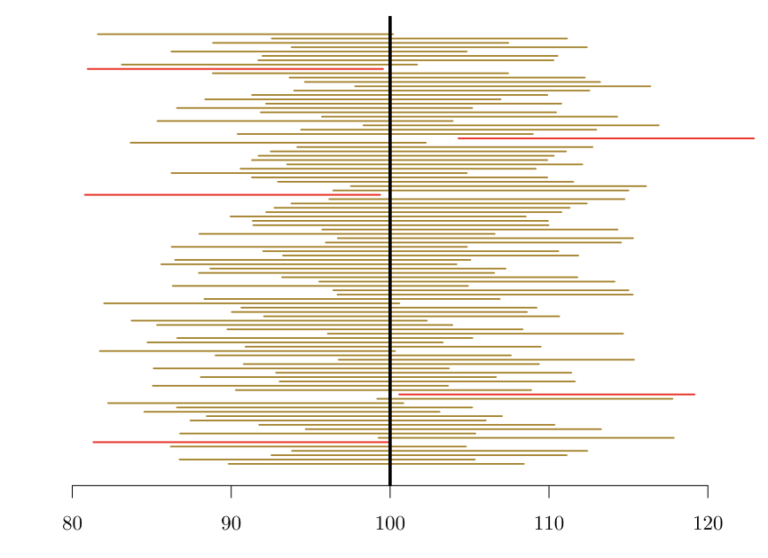

Ini adalah hasil perhitungan CI dalam 100 kali percobaan dengan asumsi kita sudah mengetahui true means (=100). Hanya ada 95 hasil CI yang bisa tepat berada pada rentang nilai true means, sisanya salah.

Maka dari itu, perhitungan tadi **(352.68, 376.09)**, belum tentu adalah hasil yang berhasil. Namun, kita bisa menginterpretasikan semaksimal mungkin dengan interpretasi yang sudah dijelaskan sebelumnya.

`sample estimates` hanya mengindikasikan nilai tengah dari rentang yang dihitung (estimasi titik).

**Hati-hati dalam interpretasi p-value!**

Kita akan sering menggunakan kata **signifikan** pada hasil kita, namun kata tersebut cenderung keliru jika hanya digunakan tanpa keterangan lebih lengkap. Kata kuncinya, p-value juga sama seperti CI, salah satu parameter frequentist yang pada perhitungannya harus dilakukan berulang dengan sampel-sampel yang berbeda. Lalu, pada interpretasi p-value, kita hanya bisa **menolak** suatu **mempertahankan** suatu hipotesis null. Utamanya adalah **hipotesis null**, anggapkan hipotesis alternatif itu adalah suatu hal yang tidak kita ketahui dan harus kita uji lebih lanjut di kesempatan lain.

Berikut adalah contoh interpretasi yang baik (dan aman) untuk kasus hasil di atas (hasil p-value<0.05).

Dalam konteks hipotesa yang diuji pada t-test,

- **Hipotesis Nol (H0)**: Rata-rata dari `data$realSum` sama dengan 0.
- **Hipotesis Alternatif (H1)**: Rata-rata dari `data$realSum` tidak sama dengan 0.

**Perbedaan yang diamati** pada nilai rata-rata `data$realSum` adalah **signifikan**. Jika kita mengasumsikan bahwa tidak ada perbedaan antara rata-rata populasi dan nol (hipotesis nol benar), maka **mengamati perbedaan** sebesar ini pada sampel yang kita miliki **akan sangat tidak mungkin terjadi**. Oleh karena itu, kita **menolak hipotesis nol** dan, untuk sementara, **bertindak seolah-olah hipotesis alternatif adalah benar**, yaitu rata-rata populasi tidak sama dengan nol.

Interpretasi ini akan berlaku ke estimasi-estimasi interval berikutnya.

Baca lebih lanjut terkait misinterpretasi ini pada paper berikut:

- Greenland, S., Senn, S. J., Rothman, K. J., et al. (2016). Statistical tests, -values, confidence intervals, and power: A guide to misinterpretations. European Journal of Epidemiology, 31, 337–350 DOI: https://doi.org/10.1007/s10654-016-0149-3
- Hoekstra, R., Morey, R. D., Rouder, J. N., & Wagenmakers, E.-J. (2014). Robust misinterpretation of confidence intervals, 21, 1157-1164 DOI: https://doi.org/10.3758/s13423-013-0572-3
- Goodman, S. (2008). A dirty dozen: Twelve -value misconceptions, 45, 135-140. DOI: https://doi.org/10.1053/j.seminhematol.2008.04.003

#### 2. Estimasi Rata-Rata 2 Sampel Berpasangan

Pasa kasus ini kita akan membandingkan perbedaan nilai antara jarak ke city center dan metro terdekat dari suatu lokasi listing Airbnb ini.

```r
# Menghitung paired t-test
result <- t.test(data$dist, data$metro_dist, paired = TRUE)

# Menampilkan confidence interval spesifik
result
```

```
##
##  Paired t-test
##
## data:  data$dist and data$metro_dist
## t = 154.97, df = 5378, p-value < 2.2e-16
## alternative hypothesis: true mean difference is not equal to 0
## 95 percent confidence interval:
##  4.256552 4.365621
## sample estimates:
## mean difference
##        4.311087
```

Hipotesa yang diuji,

- **Hipotesis Nol (H0)**: Tidak ada perbedaan rata-rata antara `data$dist` (jarak ke pusat kota) dan `data$metro_dist` (jarak ke stasiun metro terdekat), yaitu rata-rata perbedaan adalah 0.
- **Hipotesis Alternatif (H1)**: Ada perbedaan rata-rata antara `data$dist` dan `data$metro_dist`, yaitu rata-rata perbedaan tidak sama dengan 0.

**Interpretasi p-value:**

Perbedaan yang diamati pada rata-rata antara `data$dist` dan `data$metro_dist` adalah signifikan (p<0.05). Jika kita mengasumsikan bahwa tidak ada perbedaan antara rata-rata populasi kedua variabel ini (hipotesis nol benar), maka peluang untuk mengamati perbedaan sebesar ini dalam sampel yang kita miliki akan sangat kecil, dengan p-value < 2.2e-16. Oleh karena itu, kita menolak hipotesis nol (untuk sementara) dan menganggap bahwa rata-rata perbedaan antara `data$dist` dan `data$metro_dist` adalah tidak sama dengan nol.

**Interpretasi CI:**

Interval kepercayaan 95% untuk rata-rata perbedaan antara `data$dist` dan `data$metro_dist` adalah **(4.256552, 4.365621)**, dihitung melalui suatu prosedur yang dalam pengambilan sampelnya berulang, memiliki probabilitas 95% untuk mengandung nilai parameter yang sebenarnya.

Kesimpulan sementara yang bisa diambil: jarak listing Airbnb di London ini cenderung lebih jauh jaraknya ke city center dibandingkan dengan ke metro station terdekat.

#### 3. Estimasi Proporsi 1 Sampel

Pasa kasus ini kita akan memperkirakan proporsi room yang private atau tidak.

```r
# Mengonversi "TRUE" menjadi 1 dan "FALSE" menjadi 0
data$room_shared_new <- as.numeric(data$room_shared)
data$room_private_new <- as.numeric(data$room_private)
```

```r
# Melakukan estimasi proporsi dengan prop.test
result_private <- prop.test(sum(data$room_private_new), nrow(data), conf.level = 0.95)
result_private
```

```
##
##  1-sample proportions test with continuity correction
##
## data:  sum(data$room_private_new) out of nrow(data), null probability 0.5
## X-squared = 44.273, df = 1, p-value = 2.856e-11
## alternative hypothesis: true p is not equal to 0.5
## 95 percent confidence interval:
##  0.5320272 0.5588166
## sample estimates:
##         p
## 0.5454545
```

Hipotesa yang diuji,

- **Hipotesis Nol (H0)**: proporsi yang diamati pada sampel sama dengan proporsi yang diharapkan berdasarkan asumsi dasar (dalam hal ini, 0.5 atau 50%).
- **Hipotesis Alternatif (H1)**: proporsi yang diamati pada sampel berbeda dari proporsi yang diharapkan (0.5).

**Interpretasi p-value:**

Nilai **p-value = 2.856e-11** menunjukkan perbedaan antara proporsi yang diamati (p = 0.545) dan proporsi yang diharapkan (p = 0.5). Jika tidak ada perbedaan nyata (jika hipotesis nol benar), maka kemungkinan mengamati perbedaan sebesar ini pada sampel sangat kecil. Oleh karena itu, kita menolak hipotesis nol dan, untuk sementara, bertindak seolah-olah hipotesis alternatif adalah benar, yaitu bahwa proporsi yang sebenarnya **tidak sama dengan 0.5**. Dengan kata lain, proporsi **room_private_new** pada sampel ini berbeda secara signifikan dari 0.5.

**Interpretasi Interval Kepercayaan (Confidence Interval):**

Interval kepercayaan 95% untuk proporsi adalah (0.5320272, 0.5588166), dihitung melalui suatu prosedur yang dalam pengambilan sampelnya berulang, memiliki probabilitas 95% untuk mengandung nilai parameter yang sebenarnya.

Dengan interpretasi ini, kita bisa menyimpulkan bahwa proporsi **room_private_new** tidak sama dengan 50%, dan kita dapat memperkirakan rentang proporsi yang sebenarnya di populasi.

### Analisis Inferensial: Uji Hipotesa

#### 1. Uji rata-rata satu sampel

Pada uji ini, kita akan menguji hipotesa berikut:

Buat Hipotesa Awal, yaitu menyatakan nilai μ sebagai rata-rata populasi sehingga:

$H_{0}: rata-rata harga listing = 350$

$H_{1}: rata-rata harga listing ≠ 350$

```r
# melakukan ttest
result <- t.test(data$realSum, mu=350)

result
```

```
##
##  One Sample t-test
##
## data:  data$realSum
## t = 2.4109, df = 5378, p-value = 0.01595
## alternative hypothesis: true mean is not equal to 350
## 95 percent confidence interval:
##  352.6890 376.0905
## sample estimates:
## mean of x
##  364.3897
```

Interpretasi yang dilakukan tidak berbeda jauh dari estimasi pada bagian sebelumnya. Namun, hipotesa pada tes ini kita yang menentukan nilainya.

**Interpretasi p-value:**

Perbedaan yang diamati pada nilai rata-rata **data$realSum** adalah signifikan (p<0.05). Jika kita mengasumsikan bahwa tidak ada perbedaan antara rata-rata populasi dan 350 (hipotesis nol benar), maka mengamati perbedaan sebesar ini pada sampel yang kita miliki akan sangat tidak mungkin terjadi. Oleh karena itu, kita menolak hipotesis nol dan, untuk sementara, bertindak seolah-olah hipotesis alternatif adalah benar, yaitu rata-rata populasi **tidak sama dengan 350**.

**Interpretasi Interval Kepercayaan (Confidence Interval):**

Interval kepercayaan 95% (352.69, 376.09) dihitung melalui suatu prosedur yang dalam pengambilan sampelnya berulang, memiliki probabilitas 95% untuk mengandung nilai parameter yang sebenarnya.

#### 2. Uji proporsi 1 sampel

Pasa kasus ini kita akan menguji proporsi room yang private atau tidak dengan hipotesis awal.

$H_{0}: proporsi private = 0.54$

$H_{1}: proporsi private ≠ 0.54$

```r
# Melakukan uji proporsi 1 sampel
prop.test(sum(data$room_private_new), nrow(data), p = 0.54, alternative = "two.sided")
```

```
##
##  1-sample proportions test with continuity correction
##
## data:  sum(data$room_private_new) out of nrow(data), null probability 0.54
## X-squared = 0.6225, df = 1, p-value = 0.4301
## alternative hypothesis: true p is not equal to 0.54
## 95 percent confidence interval:
##  0.5320272 0.5588166
## sample estimates:
##         p
## 0.5454545
```

- `sum(data$room_private_new)`: Jumlah room yang private (nilai 1).
- `nrow(data)`: Total jumlah sampel.
- `p = 0.54`: Proporsi null yang diuji (H0: proporsi = 0.54).
- `alternative = "two.sided"`: Hipotesis alternatif (H1) adalah bahwa proporsi tidak sama dengan 0.54 (dua sisi).

**Interpretasi p-value:**

Perbedaan yang diamati pada proporsi `data$room_private_new` dibandingkan dengan proporsi 0.54 **tidak** signifikan (p = 0.4301). Jika kita mengasumsikan bahwa tidak ada perbedaan antara proporsi populasi dan 0.54 (hipotesis nol benar), maka mengamati perbedaan sebesar ini pada sampel yang kita miliki **bukan hal yang tidak mungkin terjadi**. Oleh karena itu, kita **tidak** menolak hipotesis nol dan, untuk sementara, bertindak seolah-olah hipotesis alternatif tidak benar, yaitu proporsi populasi sama dengan 0.54.

**Interpretasi Interval Kepercayaan (Confidence Interval):**

Interval kepercayaan 95% (0.5320272, 0.5588166) dihitung melalui suatu prosedur yang, dalam pengambilan sampelnya berulang, memiliki probabilitas 95% untuk mengandung nilai parameter yang sebenarnya.

#### 3. Uji perbedaan rata-rata independen (dua sampel)

Pasa kasus ini kita akan menguji apakah ada perbedaan jarak terhadap pusat kota antara listing Airbnb yang memiliki room private dan tidak.

$H_{0}: diff = 0$

$H_{1}: diff ≠ 0$

diff: mean jarak listing room private - mean jarak listing tidak private

```r
# pisahkan terlebih dahulu
jarak_private <- data$dist[data$room_private_new == 1]
head(jarak_private)
```

```
## [1] 5.734117 4.788905 4.596677 2.054769 1.787295 2.430836
```

```r
jarak_tidak_private <- data$dist[data$room_private_new == 0]
head(jarak_tidak_private)
```

```
## [1] 4.491277 4.467894 1.490442 7.723491 5.301029 3.409038
```

```r
# Melakukan uji t dua sampel untuk perbedaan rata-rata
t.test(jarak_private, jarak_tidak_private, alternative = "two.sided")
```

```
##
##  Welch Two Sample t-test
##
## data:  jarak_private and jarak_tidak_private
## t = 13.245, df = 5359, p-value < 2.2e-16
## alternative hypothesis: true difference in means is not equal to 0
## 95 percent confidence interval:
##  0.8139943 1.0968175
## sample estimates:
## mean of x mean of y
##  5.761896  4.806490
```

**Interpretasi p-value:**

Perbedaan yang diamati pada nilai rata-rata jarak antara listing Airbnb dengan room private dan tidak private adalah signifikan (p < 0.05). Jika kita mengasumsikan bahwa tidak ada perbedaan antara rata-rata populasi untuk kedua kelompok (hipotesis nol benar), maka mengamati perbedaan sebesar ini pada sampel yang kita miliki akan sangat tidak mungkin terjadi. Oleh karena itu, kita menolak hipotesis nol dan, untuk sementara, bertindak seolah-olah hipotesis alternatif adalah benar, yaitu rata-rata jarak listing dengan room private tidak sama dengan rata-rata jarak listing yang tidak private.

**Interpretasi Interval Kepercayaan (Confidence Interval):**

Interval kepercayaan 95% (0.8139943, 1.0968175) dihitung melalui suatu prosedur yang, dalam pengambilan sampelnya berulang, memiliki probabilitas 95% untuk mengandung nilai parameter.

#### 4. Uji Perbedaan Rata-rata Berpasangan sampel (dua Sampel)

Pasa kasus ini kita akan menguji apakah ada perbedaan nilai antara jarak terhadap pusat kota dan metro stasiun terdekat

$H_{0}: diff = 0$

$H_{1}: diff ≠ 0$

diff: mean jarak terhadap pusat - mean jarak terhadap metro stasiun terdekat.

```r
# Melakukan uji t berpasangan
t.test(data$dist, data$metro_dist, paired = TRUE, alternative = "two.sided")
```

```
##
##  Paired t-test
##
## data:  data$dist and data$metro_dist
## t = 154.97, df = 5378, p-value < 2.2e-16
## alternative hypothesis: true mean difference is not equal to 0
## 95 percent confidence interval:
##  4.256552 4.365621
## sample estimates:
## mean difference
##        4.311087
```

- `data$dist`: Jarak terhadap pusat kota.
- `data$metro_dist`: Jarak terhadap metro stasiun terdekat.
- `paired = TRUE`: Menyatakan bahwa ini adalah uji t berpasangan.
- `alternative = "two.sided"`: Hipotesis alternatif adalah bahwa perbedaan rata-rata tidak sama dengan nol (dua sisi).

**Interpretasi p-value:**

Perbedaan yang diamati pada nilai rata-rata antara jarak terhadap pusat kota dan jarak terhadap metro stasiun terdekat adalah signifikan (p < 0.05). Jika kita mengasumsikan bahwa tidak ada perbedaan antara rata-rata populasi untuk kedua jarak tersebut (hipotesis nol benar), maka mengamati perbedaan sebesar ini pada sampel yang kita miliki akan sangat tidak mungkin terjadi. Oleh karena itu, kita menolak hipotesis nol dan, untuk sementara, bertindak seolah-olah hipotesis alternatif adalah benar, yaitu rata-rata jarak terhadap pusat kota tidak sama dengan rata-rata jarak terhadap metro stasiun terdekat.

**Interpretasi Interval Kepercayaan (Confidence Interval):**

Interval kepercayaan 95% (4.256552, 4.365621) dihitung melalui suatu prosedur yang, dalam pengambilan sampelnya berulang, memiliki probabilitas 95% untuk mengandung nilai perbedaan rata-rata yang sebenarnya.

#### 5. Uji 2 Proporsi Independen

Pasa kasus ini kita akan menguji apakah ada perbedaan proporsi antara room shared dan room private.

$H_{0}: diff = 0$

$H_{1}: diff ≠ 0$

diff: proporsi room shared - proporsi room private

```r
# Hitung jumlah room shared dan room private
shared_count <- sum(data$room_shared)
private_count <- sum(data$room_private)

# Total sampel masing-masing kategori
shared_total <- length(data$room_shared)
private_total <- length(data$room_private)
```

```r
# Melakukan uji proporsi independen
prop.test(c(shared_count, private_count), c(shared_total, private_total), alternative = "two.sided")
```

```
##
##  2-sample test for equality of proportions with continuity correction
##
## data:  c(shared_count, private_count) out of c(shared_total, private_total)
## X-squared = 3935.1, df = 1, p-value < 2.2e-16
## alternative hypothesis: two.sided
## 95 percent confidence interval:
##  -0.5540608 -0.5268092
## sample estimates:
##     prop 1     prop 2
## 0.00501952 0.54545455
```

**Interpretasi p-value:**

Perbedaan yang diamati pada proporsi antara room shared dan room private adalah signifikan (p < 0.05). Jika kita mengasumsikan bahwa tidak ada perbedaan antara proporsi populasi room shared dan room private (hipotesis nol benar), maka mengamati perbedaan sebesar ini pada sampel yang kita miliki akan sangat tidak mungkin terjadi. Oleh karena itu, kita menolak hipotesis nol dan, untuk sementara, bertindak seolah-olah hipotesis alternatif adalah benar, yaitu proporsi room shared tidak sama dengan proporsi room private.

**Interpretasi Interval Kepercayaan (Confidence Interval):**

Interval kepercayaan 95% (-0.5540608, -0.5268092) dihitung melalui suatu prosedur yang, dalam pengambilan sampelnya berulang, memiliki probabilitas 95% untuk mengandung nilai perbedaan proporsi yang sebenarnya.

**Kesimpulan:** Proporsi room private (sekitar 0.545) jauh lebih besar dibandingkan dengan room shared (sekitar 0.005), dengan perbedaan proporsi yang signifikan secara statistik.